# Homework Assignment 2

Wei Shi

# 1 Problem 1

## 1.1 (a)

$$\begin{align}
\ell(\theta) & = \ln \left\{ \prod_{i = 1}^{n} \frac{1}{\pi [1 + (\theta-x_i)^2]}\right\}
= - \sum_{i = 1}^{n} \left\{\ln \pi + \ln [1 + (\theta- x_i)^2]\right\}
= -n \ln \pi - \sum_{i = 1}^{n} \ln [1+ (\theta - x_i)^2]\\
\ell'(\theta) & = - \sum_{i = 1}^{n} \frac{\partial}{\partial \theta} \ln [1+ (\theta- x_i)^2]
= - \sum_{i=1}^{n} \frac{\frac{\partial}{\partial \theta} [1+ (\theta-x_i)^2]}{1+ (\theta-x_i)^2}
= -2 \sum_{i=1}^{n} \frac{\theta-x_i}{1+ (\theta-x_i)^2}\\
\ell''(\theta) & = -2 \sum_{i=1}^{n} \frac{\partial}{\partial \theta} \frac{\theta-x_i}{1+ (\theta-x_i)^2}
= -2 \sum_{i=1}^{n} \frac{1+ (\theta-x_i)^2-2(\theta-x_i)^2}{[1+ (\theta-x_i)^2]^2}
= -2 \sum_{i=1}^{n} \frac{1-(\theta-x_i)^2}{[1+ (\theta-x_i)^2]^2}\\
I(\theta) & = n \int_{-\infty}^{\infty} \frac{\{p'(x)\}^2}{p(x)} dx
= n \int_{-\infty}^{\infty} \frac{\left\{-\frac{2(x-\theta)}{\pi [1+(x-\theta)^2]^2}\right\}^2}
{\frac{1}{\pi [1+(x-\theta)^2]}} dx
= \frac{4n}{\pi} \int_{-\infty}^{\infty} \frac{(x-\theta)^2}{[1+(x-\theta)^2]^3} dx \text{ (let } y=x-\theta)\\
& = \frac{4n}{\pi} \int_{-\infty}^{\infty} \frac{y^2}{1+y^3} dy = \frac{n}{2}
\end{align}$$

```r
#calculate the above integration times 4/pi
f <- function(y) {y^2 / (1 + y^2)^3}
integrate(f, -Inf, Inf)$value * 4 / pi
```

```
## [1] 0.5
```

## 1.2 (b)

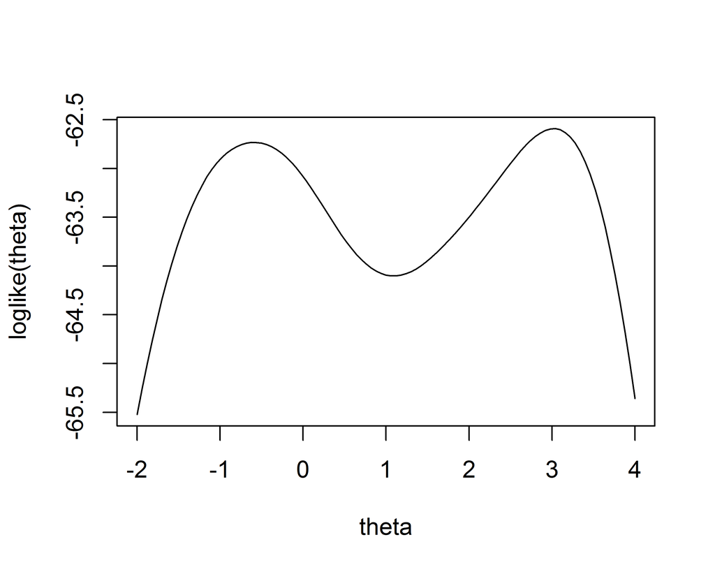

Figure 1.1: Log-likelihood function.

```r
x1 <- c(1.77, -0.23, 2.76, 3.80, 3.47, 56.75, -1.34, 4.24, -2.44,
      3.29, 3.71, -2.40, 4.53, -0.07, -1.05, -13.87, -2.53, -1.75)

loglike1 <- function(theta){
  sapply(theta, function(theta) {-length(x1) * log(pi) - sum(log(1 + (theta - x1)^2))})
}

curve(loglike1(theta), from = -2, to = 4, xname = "theta", ylab = "loglike(theta)")
```

From the above plot, we can see that the global maximum is attained around 3, however there is a local maximum attained around -0.5 which is very closed to the global maximum.

To maximize $\ell(\theta)$, Newton-Raphson method computes
$$\begin{align}
\theta_{t+1} = \theta_t - \frac{\ell'(\theta_t)}{\ell''(\theta_t)}
\end{align}$$

```r
NewtonRaphson <- function(start, g, gr.g, hess.g){
  sapply(start, function(start) {nlminb(start = start, g, gr.g, hess.g)}[c(1, 4)])
}

start1 <- c(-11, -1, 0, 1.5, 4, 4.7, 7, 8, 38)

nllh1 <- function(theta){ # negative log-likelihood
  length(x1) * log(pi) + sum(log(1 + (theta - x1)^2))
}

gr.nllh1 <- function(theta){
  2 * sum((theta - x1) / (1 + (theta - x1)^2))
}

hess.nllh1 <- function(theta){
  as.matrix(2 * sum((1 - (theta - x1)^2) / (1 + (theta - x1)^2)^2))
}

table1 <- data.frame(NewtonRaphson(c(start1, mean(x1)), nllh1, gr.nllh1, hess.nllh1))
colnames(table1) <- c(start1, paste("mean = ", round(mean(x1), digits = 4)))
rownames(table1) <- c("MLE", "iterations")

knitr::kable(table1, booktabs = TRUE, digits = 4,
             caption = 'MLE for \(\theta\) using the Newton-Raphson method.')
```

Table 1.1: MLE for $\theta$ using the Newton-Raphson method.

|  | -11 | -1 | 0 | 1.5 | 4 | 4.7 | 7 | 8 | 38 | mean = 3.2578 |
| --- | --- | --- | --- | --- | --- | --- | --- | --- | --- | --- |
| MLE | 3.021 | -0.5915 | -0.5915 | 3.021 | 3.021 | 3.021 | 3.021 | 3.021 | 3.021 | 3.021 |
| iterations | 6 | 4 | 4 | 7 | 4 | 7 | 5 | 8 | 9 | 4 |

From the above table, we can see that when starting from -1 and 0, it stucks at the local maximum. All the other starting points work well, Newton-Raphson method finds the correct MLE and the minimal number of iterations is 4. By comparison, we can conclude that the sample mean is a good starting point because it goes to the correct MLE with minimal number of iterations.

## 1.3 (c)

For fixed-point iterations, compute
$$\begin{align}
\theta_{t+1} = \theta_t + \alpha\ell'(\theta_t)
\end{align}$$

```r
FixedPoint <- function(start, g, gr.g, scale){
  sapply(scale, function(alpha) {
    NewtonRaphson(start, g, gr.g, function(theta) {as.matrix(1/alpha)})
    })
}

scale <- c(1, 0.64, 0.25)

result1 <- FixedPoint(start1, nllh1, gr.nllh1, scale)
table2 <- vector("list", length(scale))
for (i in 1:length(scale)){
  table2[[i]] <- data.frame(matrix(result1[, i], nrow = 2))
  colnames(table2[[i]]) <- start1
  rownames(table2[[i]]) <- c("MLE", "iterations")
}

knitr::kable(table2[[1]], booktabs = TRUE, digits = 4,
             caption = 'Fixed-point iterations when \(\alpha\) = 1.')
```

Table 1.2: Fixed-point iterations when $\alpha$ = 1.

|  | -11 | -1 | 0 | 1.5 | 4 | 4.7 | 7 | 8 | 38 |
| --- | --- | --- | --- | --- | --- | --- | --- | --- | --- |
| MLE | -0.5915 | -0.5915 | -0.5915 | 3.021 | 3.021 | 3.021 | 3.021 | -0.5914 | -0.5915 |
| iterations | 13 | 6 | 6 | 7 | 5 | 6 | 6 | 9 | 29 |

```r
knitr::kable(table2[[2]], booktabs = TRUE, digits = 4,
             caption = 'Fixed-point iterations when \(\alpha\) = 0.64.')
```

Table 1.2: Fixed-point iterations when $\alpha$ = 0.64.

|  | -11 | -1 | 0 | 1.5 | 4 | 4.7 | 7 | 8 | 38 |
| --- | --- | --- | --- | --- | --- | --- | --- | --- | --- |
| MLE | 3.021 | -0.5915 | -0.5915 | 3.021 | 3.021 | 3.021 | 3.021 | -0.5915 | 3.021 |
| iterations | 9 | 8 | 8 | 7 | 4 | 5 | 4 | 10 | 42 |

```r
knitr::kable(table2[[3]], booktabs = TRUE, digits = 4,
             caption = 'Fixed-point iterations when \(\alpha\) = 0.25.')
```

Table 1.2: Fixed-point iterations when $\alpha$ = 0.25.

|  | -11 | -1 | 0 | 1.5 | 4 | 4.7 | 7 | 8 | 38 |
| --- | --- | --- | --- | --- | --- | --- | --- | --- | --- |
| MLE | -0.5915 | -0.5915 | -0.5914 | 3.021 | 3.021 | 3.021 | 3.021 | 3.021 | 3.021 |
| iterations | 22 | 14 | 14 | 10 | 5 | 7 | 9 | 8 | 91 |

From the above three tables, we can see that extreme starting points such as -11, -1, 0, 8 and 38 are more likely to stuck at local maximum.

## 1.4 (d)

For Fisher scoring, compute
$$\begin{align}
\theta_{t+1} = \theta_t + \frac{\ell'(\theta_t)}{I(\theta_t)}
\end{align}$$

```r
FisherNewton <- function(start, g, gr.g, info, hess.g){
  sapply(start, function(start){
    fisher.result <- nlminb(start = start, g, gr.g, info)[c(1, 4)]
    newton.result  <- nlminb(start = fisher.result[1], g, gr.g, hess.g)[c(1, 4)]
    c(newton.result[1], fisher.result[2], newton.result[2])
  })
}

info1 <- function(theta) {as.matrix(length(x1)/2)}

table3 <- data.frame(FisherNewton(start1, nllh1, gr.nllh1, info1, hess.nllh1))
colnames(table3) <- start1
rownames(table3) <- c("MLE", "fisher iterations", "Netwon iterations")
knitr::kable(table3, booktabs = TRUE, digits = 4,
             caption = 'Fisher scoring + Newton-Raphson method.')
```

Table 1.3: Fisher scoring + Newton-Raphson method.

|  | -11 | -1 | 0 | 1.5 | 4 | 4.7 | 7 | 8 | 38 |
| --- | --- | --- | --- | --- | --- | --- | --- | --- | --- |
| MLE | -0.5915 | -0.5915 | -0.5915 | 3.021 | 3.021 | 3.021 | 3.021 | 3.021 | -0.5915 |
| fisher iterations | 56 | 33 | 35 | 29 | 16 | 17 | 20 | 22 | 150 |
| Netwon iterations | 2 | 2 | 2 | 1 | 1 | 1 | 1 | 1 | 7 |

From above table, we can see that when starting from -11, -1, 0 and 38, the algorithm stops at the local maximum. And number of iterations for fisher scoring are pretty high.

## 1.5 (e)

Compare the results in (b), (c) and (d), finding the MLE using Newton-Raphson method is preferable since it uses less number of iterations and is more stable with different starting points. The main reason is that in this problem, we can compute $\ell'(\theta)$ and $\ell''(\theta)$ analytically.

# 2 Problem 2

## 2.1 (a)

$$\begin{align}
\ell(\theta) = \ln \left\{ \prod_{i = 1}^{n} \frac{1-\cos(x_i - \theta)}{2\pi}\right\}
= -n \ln (2\pi) + \sum_{i = 1}^{n} \ln [1 - \cos(x_i - \theta)]
\end{align}$$

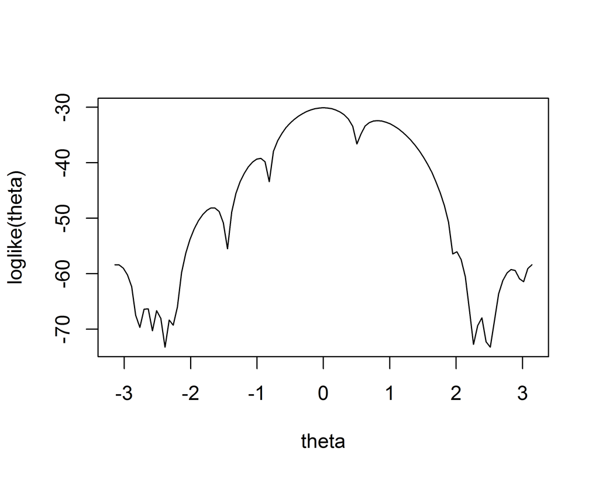

Figure 2.1: Log-likelihood function.

```r
x2 <- c(3.91, 4.85, 2.28, 4.06, 3.70, 4.04, 5.46, 3.53, 2.28, 1.96,
       2.53, 3.88, 2.22, 3.47, 4.82, 2.46, 2.99, 2.54, 0.52)

loglike2 <- function(theta){
  sapply(theta, function(theta) {-length(x2) * log(2 * pi) + sum(log(1 - cos(x2 - theta)))})
}

curve(loglike2(theta), from = -pi, to = pi, xname = "theta", ylab = "loglike(theta)")
```

From above plot, we can see that the global maximum is attained around 0.

## 2.2 (b)

$$\begin{align}
\mathbb{E}(X|\theta) & = \int_0^{2\pi} x p(x|\theta) dx
= \frac{1}{2\pi}\int_0^{2\pi} (x - x \cos(x - \theta)) dx \\
& = \frac{1}{2\pi} \{\frac{1}{2}x^2 |_0^{2\pi} - [x\sin(x-\theta)|_0^{2\pi} + \cos(x-\theta)|_0^{2\pi}]\}
= \pi + \sin(\theta) \\
\Rightarrow \hat{\theta}_{\text{moment}} & = \arcsin(\bar{x} - \pi)\\
\end{align}$$

```r
theta.mom <- asin(mean(x2) - pi)
theta.mom
```

```
## [1] 0.09539
```

## 2.3 (c)

$$\begin{align}
\ell'(\theta) & = - \sum_{i=1}^n \frac{\sin(x_i - \theta)}{1 - \cos(x_i - \theta)}\\
\ell''(\theta) & = - \sum_{i=1}^n \frac{1}{1 - \cos(x_i - \theta)}\\
\end{align}$$

```r
nllh2 <- function(theta){ # negative log-likelihood
  length(x2) * log(2 * pi) - sum(log(1 - cos(x2 - theta)))
}

gr.nllh2 <- function(theta){
  sum(sin(x2 - theta) / (1 - cos(x2 - theta)))
}

hess.nllh2 <- function(theta){
  as.matrix(sum(1  / (1 - cos(x2 - theta))))
}

table6 <- data.frame(NewtonRaphson(start = theta.mom, nllh2, gr.nllh2, hess.nllh2))
colnames(table6) <- round(theta.mom, digits = 4)
rownames(table6) <- c("MLE", "iterations")

knitr::kable(table6, booktabs = TRUE, digits = 4,
             caption = 'MLE for \(\theta\) using the Newton-Raphson method with \(\theta_0 = \hat{\theta}_{\text{moment}}\).')
```

Table 2.1: MLE for $\theta$ using the Newton-Raphson method with $\theta_0 = \hat{\theta}_{\text{moment}}$.

|  | 0.0954 |
| --- | --- |
| MLE | 0.003118 |
| iterations | 4 |

## 2.4 (d)

```r
table7 <- data.frame(NewtonRaphson(start = c(-2.7, 2.7), nllh2, gr.nllh2, hess.nllh2))
colnames(table7) <- c(-2.7, 2.7)
rownames(table7) <- c("MLE", "iterations")

knitr::kable(table7, booktabs = TRUE, digits = 4,
             caption = 'MLE for \(\theta\) using the Newton-Raphson method.')
```

Table 2.2: MLE for $\theta$ using the Newton-Raphson method.

|  | -2.7 | 2.7 |
| --- | --- | --- |
| MLE | -2.669 | 2.848 |
| iterations | 4 | 5 |

## 2.5 (e)

```r
start2 <- seq(-pi, pi, length.out = 200)
result2 <- as.numeric(NewtonRaphson(start = start2, nllh2, gr.nllh2, hess.nllh2)[1, ])
table8 <- data.frame(cbind(round(result2, digits = 4), round(start2, digits = 4)))
colnames(table8) <- c("outcome", "start")
sets <-sapply(unique(table8$outcome), function(x) {
  as.character(table8$start[which(table8$outcome==x)])
})
table9 <- data.frame(cbind(unique(table8$outcome), sets))
colnames(table9) <- c("unique outcome", "starting values")
knitr::kable(table9, booktabs = TRUE, digits = 4,
             caption = 'Sets of attraction.')
```

Table 2.3: Sets of attraction.

[output not shown]

# 3 Problem 3

## 3.1 (a)

```r
beetles <- data.frame(
days = c(0, 8, 28, 41, 63, 69, 97, 117, 135, 154),
beetles = c(2, 47, 192, 256, 768, 896, 1120, 896, 1184, 1024))

N0 <- 2

result3 <- nls(beetles ~ K * N0 / (N0 + (K - N0) * exp(-r * days)),
               data = beetles, start = list(K = 1200, r = 0.1))
summary(result3)
```

```
##
## Formula: beetles ~ K * N0/(N0 + (K - N0) * exp(-r * days))
##
## Parameters:
##   Estimate Std. Error t value Pr(>|t|)
## K 1.05e+03   4.72e+01    22.2  1.8e-08 ***
## r 1.18e-01   6.53e-03    18.1  8.9e-08 ***
## ---
## Signif. codes:  0 '***' 0.001 '**' 0.01 '*' 0.05 '.' 0.1 ' ' 1
##
## Residual standard error: 95.8 on 8 degrees of freedom
##
## Number of iterations to convergence: 7
## Achieved convergence tolerance: 6.57e-06
```

## 3.2 (b)

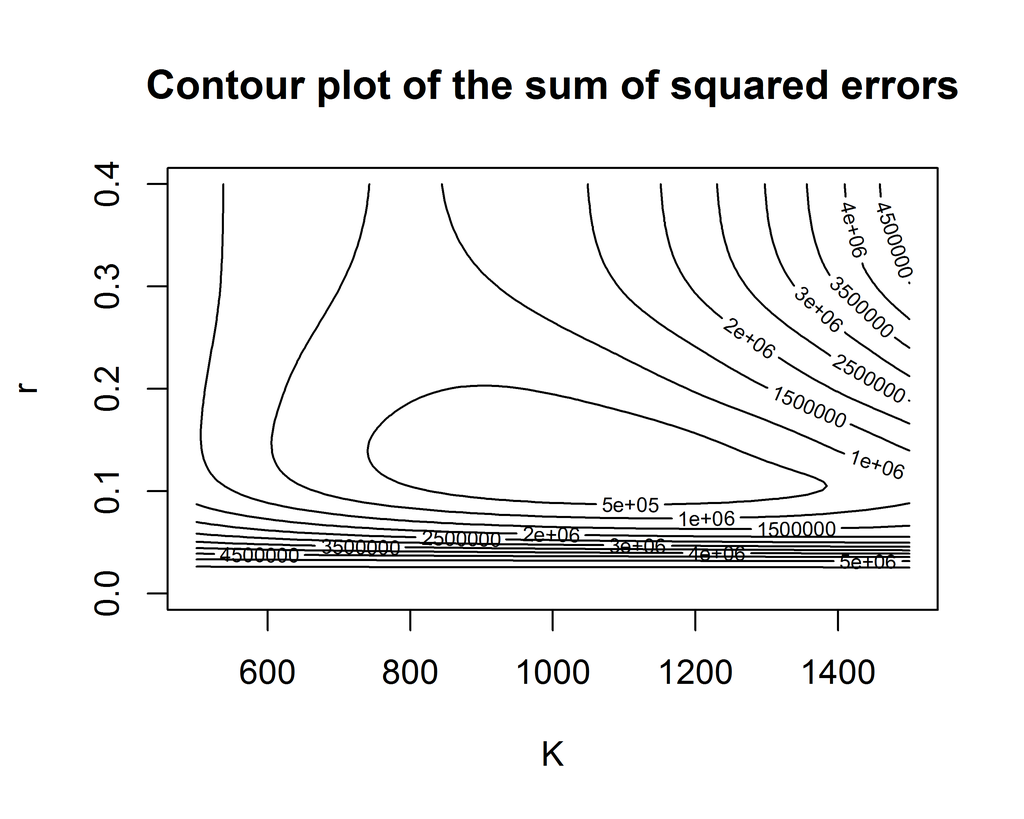

```r
K <- seq(500, 1500, length.out = 100)
r <- seq(0, 0.4, length.out = 100)
sse <- function(K, r){
  sapply(r, function(r) {
    sapply(K, function(K){
    sum((beetles$beetles - K * N0 / (N0 + (K - N0) * exp(-r * beetles$days)))^2)})})
}
contour(K, r, sse(K, r),
        main = "Contour plot of the sum of squared errors",
        xlab = "K", ylab = "r" )
```

## 3.3 (c)

```r
nloglike3 <- function(x){ # x = c(r, K, sigma)
  length(beetles$beetles) * log(sqrt(2 * pi) * x[3]) +
    1 / x[3]^2 * sum(log(beetles$beetles) - log(x[2] * N0 / (N0 + (x[2] - N0) * exp(-x[1] * beetles$days))))
}

mle <- optim(par = c(0.118, 1049.408, 1), fn = nloglike3)$par
var <- diag(optimHess(par = c(0.118, 1049.408, 1), fn = nloglike3))
table10 <- data.frame(rbind(mle, var))
colnames(table10) <- c("r", "K", "sigma")
knitr::kable(table10, booktabs = TRUE, digits = 4,
             caption = 'MLE and variance of estimates using Nelder-Mead method.')
```

|  | r | K | sigma |
| --- | --- | --- | --- |
| mle | 89.07 | 1011 | 0.00 |
| var | 1623.92 | 0 | 12.22 |